### Unit 3: Penguins

#### Lesson 3: t-tests

#### New functions:

identify_outliers(), stat_qq(), t.test(), t_test(), kable(), cohens_d(), droplevels(), levene_test()

### Intro to t-tests

t-tests are used to assess the difference between two means. When conducting a t-test, you are testing the null hypothesis (H0) that the means are the same. As a standard practice in classical (frequentist) statistics, if the p-value resulting from your t-test is < 0.05, you reject the null hypothesis in favor of the alternative hypothesis, which states that the means are significantly different.

There are 3 types of t-test:

- One-sample t-test
- Independent sample t-test
- Paired t-test

We’ll use the `tidyverse` and our palmer penguins data to run through an example of each of these types of t-test. We’ll also load in the package `rstatix` because it contains pipe-friendly statistics functions that play nicely with the `tidyverse.` Don’t forget to install the `rstatix` package if it is your first time using it! I’m also going to use the kable() function in the knitr package to print out some of the results tables neatly for this tutorial. This is just for aesthetics, and is not necessary for any of the plotting or statistical tests in this lesson.

```r
library(tidyverse)
library(palmerpenguins)
library(rstatix)
library(knitr)  # prints pretty tables
```

### One-sample t-test

The one-sample t-test, also known as the single-parameter t test or single-sample t-test, is used to compare the mean of one sample to a known standard (or theoretical / hypothetical) mean. Generally, the theoretical mean comes from somewhere in the literature or from a previous experiment in your own lab.

The one-sample t-test assumes the following characteristics about the data:

- No significant outliers in the data
- Data should be approximately normally distributed

#### Exploratory data analysis

Before conducting any statistical analyses on your data, it’s imperative that you understand your data. This sounds obvious, but it’s a step that people all too often skip. Here are some great goals for exploratory data analysis:

1. Looking at the raw data values.
2. Computing summary statistics.
3. Creating data visualizations.

These are things we’ve been doing already in the course, but now that we are actually trying to run a statistical test with the penguins data, we should use the functions in base R and the tidyverse to formally run through these steps. We will be looking at the difference in body mass between the three penguin species in our observations: Gentoo, Chinstrap and Adelie.

```r
# Two great functions for looking at the first few rows of your variables:
head(penguins)
```

```
## # A tibble: 6 x 8
##   species island bill_length_mm bill_depth_mm flipper_length_… body_mass_g sex
##   <fct>   <fct>           <dbl>         <dbl>            <int>       <int> <fct>
## 1 Adelie  Torge…           39.1          18.7              181        3750 male
## 2 Adelie  Torge…           39.5          17.4              186        3800 fema…
## 3 Adelie  Torge…           40.3          18                195        3250 fema…
## 4 Adelie  Torge…           NA            NA                 NA          NA <NA>
## 5 Adelie  Torge…           36.7          19.3              193        3450 fema…
## 6 Adelie  Torge…           39.3          20.6              190        3650 male
## # … with 1 more variable: year <int>
```

```r
glimpse(penguins)
```

```
## Rows: 344
## Columns: 8
## $ species           <fct> Adelie, Adelie, Adelie, Adelie, Adelie, Adelie, Ade…
## $ island            <fct> Torgersen, Torgersen, Torgersen, Torgersen, Torgers…
## $ bill_length_mm    <dbl> 39.1, 39.5, 40.3, NA, 36.7, 39.3, 38.9, 39.2, 34.1,…
## $ bill_depth_mm     <dbl> 18.7, 17.4, 18.0, NA, 19.3, 20.6, 17.8, 19.6, 18.1,…
## $ flipper_length_mm <int> 181, 186, 195, NA, 193, 190, 181, 195, 193, 190, 18…
## $ body_mass_g       <int> 3750, 3800, 3250, NA, 3450, 3650, 3625, 4675, 3475,…
## $ sex               <fct> male, female, female, NA, female, male, female, mal…
## $ year              <int> 2007, 2007, 2007, 2007, 2007, 2007, 2007, 2007, 200…
```

```r
# Summary statistics. Note # of observations and NAs
summary(penguins)
```

```
##       species          island    bill_length_mm  bill_depth_mm
##  Adelie   :152   Biscoe   :168   Min.   :32.10   Min.   :13.10
##  Chinstrap: 68   Dream    :124   1st Qu.:39.23   1st Qu.:15.60
##  Gentoo   :124   Torgersen: 52   Median :44.45   Median :17.30
##                                  Mean   :43.92   Mean   :17.15
##                                  3rd Qu.:48.50   3rd Qu.:18.70
##                                  Max.   :59.60   Max.   :21.50
##                                  NA's   :2       NA's   :2
##  flipper_length_mm  body_mass_g       sex           year
##  Min.   :172.0     Min.   :2700   female:165   Min.   :2007
##  1st Qu.:190.0     1st Qu.:3550   male  :168   1st Qu.:2007
##  Median :197.0     Median :4050   NA's  : 11   Median :2008
##  Mean   :200.9     Mean   :4202                Mean   :2008
##  3rd Qu.:213.0     3rd Qu.:4750                3rd Qu.:2009
##  Max.   :231.0     Max.   :6300                Max.   :2009
##  NA's   :2         NA's   :2
```

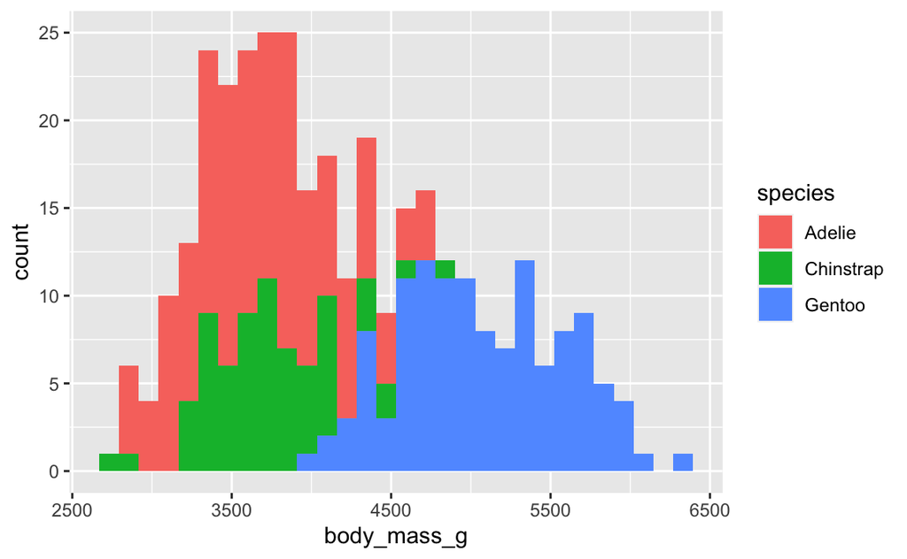

```r
ggplot(data=penguins) +
  geom_histogram(aes(x=body_mass_g, fill=species))
## `stat_bin()` using `bins = 30`. Pick better value with `binwidth`.
## Warning: Removed 2 rows containing non-finite values (stat_bin).
```